# Part I - FIFA19

## Introduction

> In this project, I will use FIFA 19 dataset, which I imported from Kaggle. FIFA 19 is part of the FIFA series of association football video games. It is one of the most popular games in the world. the dataset contaons detailed attributes for every player registered in the latest edition of FIFA 19 database.

## Preliminary Wrangling

```python
# import all packages and set plots to be embedded inline
import numpy as np
import pandas as pd
import matplotlib.pyplot as plt
import seaborn as sb

%matplotlib inline
```

```python
fifa_df = pd.read_excel('fifa19.xlsx')
fifa_df.head()
```

|  | Unnamed: 0 | ID | Name | Age | Photo | Nationality | Flag | Overall | Potential | Club | ... | Composure | Marking | StandingTackle | SlidingTackle | GKDiving | GKHandling | GKKicking | GKPositioning | GKReflexes | Release Clause |
| --- | --- | --- | --- | --- | --- | --- | --- | --- | --- | --- | --- | --- | --- | --- | --- | --- | --- | --- | --- | --- | --- |
| 0 | 0 | 158023 | L. Messi | 31 | https://cdn.sofifa.org/players/4/19/158023.png | Argentina | https://cdn.sofifa.org/flags/52.png | 94 | 94 | FC Barcelona | ... | 96.0 | 33.0 | 28.0 | 26.0 | 6.0 | 11.0 | 15.0 | 14.0 | 8.0 | €226.5M |
| 1 | 1 | 20801 | Cristiano Ronaldo | 33 | https://cdn.sofifa.org/players/4/19/20801.png | Portugal | https://cdn.sofifa.org/flags/38.png | 94 | 94 | Juventus | ... | 95.0 | 28.0 | 31.0 | 23.0 | 7.0 | 11.0 | 15.0 | 14.0 | 11.0 | €127.1M |
| 2 | 2 | 190871 | Neymar Jr | 26 | https://cdn.sofifa.org/players/4/19/190871.png | Brazil | https://cdn.sofifa.org/flags/54.png | 92 | 93 | Paris Saint-Germain | ... | 94.0 | 27.0 | 24.0 | 33.0 | 9.0 | 9.0 | 15.0 | 15.0 | 11.0 | €228.1M |
| 3 | 3 | 193080 | De Gea | 27 | https://cdn.sofifa.org/players/4/19/193080.png | Spain | https://cdn.sofifa.org/flags/45.png | 91 | 93 | Manchester United | ... | 68.0 | 15.0 | 21.0 | 13.0 | 90.0 | 85.0 | 87.0 | 88.0 | 94.0 | €138.6M |
| 4 | 4 | 192985 | K. De Bruyne | 27 | https://cdn.sofifa.org/players/4/19/192985.png | Belgium | https://cdn.sofifa.org/flags/7.png | 91 | 92 | Manchester City | ... | 88.0 | 68.0 | 58.0 | 51.0 | 15.0 | 13.0 | 5.0 | 10.0 | 13.0 | €196.4M |

5 rows × 89 columns

```python
fifa_df.info()
```

```
<class 'pandas.core.frame.DataFrame'>
RangeIndex: 18207 entries, 0 to 18206
Data columns (total 89 columns):
 #   Column                    Non-Null Count  Dtype
---  ------                    --------------  -----
 0   Unnamed: 0                18207 non-null  int64
 1   ID                        18207 non-null  int64
 2   Name                      18207 non-null  object
 3   Age                       18207 non-null  int64
 4   Photo                     18207 non-null  object
 5   Nationality               18207 non-null  object
 6   Flag                      18207 non-null  object
 7   Overall                   18207 non-null  int64
 8   Potential                 18207 non-null  int64
 9   Club                      17966 non-null  object
```

[output cut: 81 more lines]

### Data Cleaning

- Remove the columns that are not going to be used for the analysis

```python
fifa_df = fifa_df[['ID', 'Name', 'Age', 'Nationality', 'Overall', 'Potential', 'Club',
       'Value', 'Wage', 'Special', 'Preferred Foot',
       'International Reputation', 'Weak Foot', 'Skill Moves', 'Work Rate',
       'Body Type', 'Real Face', 'Position', 'Jersey Number', 'Joined',
       'Contract Valid Until', 'Height', 'Weight','Release Clause',
        'Finishing', 'Dribbling', 'Acceleration', 'Reactions', 'Strength', 'Composure']]
```

```python
fifa_df.info()
```

```
<class 'pandas.core.frame.DataFrame'>
RangeIndex: 18207 entries, 0 to 18206
Data columns (total 30 columns):
 #   Column                    Non-Null Count  Dtype
---  ------                    --------------  -----
 0   ID                        18207 non-null  int64
 1   Name                      18207 non-null  object
 2   Age                       18207 non-null  int64
 3   Nationality               18207 non-null  object
 4   Overall                   18207 non-null  int64
 5   Potential                 18207 non-null  int64
 6   Club                      17966 non-null  object
 7   Value                     18207 non-null  object
 8   Wage                      18207 non-null  object
 9   Special                   18207 non-null  int64
```

[output cut: 22 more lines]

- Fix column names for easer analysis

```python
fifa_df.columns = [column.replace(' ','_') for column in fifa_df.columns]
fifa_df.columns = [column.lower() for column in fifa_df.columns]
# check column names
fifa_df.columns
```

```
Index(['id', 'name', 'age', 'nationality', 'overall', 'potential', 'club',
       'value', 'wage', 'special', 'preferred_foot',
       'international_reputation', 'weak_foot', 'skill_moves', 'work_rate',
       'body_type', 'real_face', 'position', 'jersey_number', 'joined',
       'contract_valid_until', 'height', 'weight', 'release_clause',
       'finishing', 'dribbling', 'acceleration', 'reactions', 'strength',
       'composure'],
      dtype='object')
```

```python
# check duplicated recordes
fifa_df.duplicated().sum()
```

```
0
```

```python
# check missing values
fifa_df.isnull().sum()
```

```
id                             0
name                           0
age                            0
nationality                    0
overall                        0
potential                      0
club                         241
value                          0
wage                           0
special                        0
preferred_foot                48
international_reputation      48
weak_foot                     48
skill_moves                   48
work_rate                     48
body_type                      0
real_face                     48
position                      60
jersey_number                 60
joined                      1553
contract_valid_until         289
height                        48
weight                        48
release_clause              1564
finishing                     48
dribbling                     48
acceleration                  48
reactions                     48
strength                      48
composure                     48
dtype: int64
```

- Deal with missing values by dropping them. Since there is a few number of missing values compared to the dataset size, removing them will not affect the analysis.

```python
# drop rows with missing values
fifa_df.dropna(axis = 0, inplace=True)
fifa_df.isnull().sum()
```

```
id                          0
name                        0
age                         0
nationality                 0
overall                     0
potential                   0
club                        0
value                       0
wage                        0
special                     0
preferred_foot              0
international_reputation    0
weak_foot                   0
skill_moves                 0
work_rate                   0
body_type                   0
real_face                   0
position                    0
jersey_number               0
joined                      0
contract_valid_until        0
height                      0
weight                      0
release_clause              0
finishing                   0
dribbling                   0
acceleration                0
reactions                   0
strength                    0
composure                   0
dtype: int64
```

```python
fifa_df.shape
```

```
(16643, 30)
```

```python
fifa_df[['value','wage','release_clause','height','weight']].sample(10)
```

|  | value | wage | release_clause | height | weight |
| --- | --- | --- | --- | --- | --- |
| 6339 | €675K | €2K | €844K | 6'3 | 168lbs |
| 1316 | €7.5M | €1K | €16.5M | 5'10 | 163lbs |
| 7999 | €160K | €1K | €200K | 5'9 | 159lbs |
| 10573 | €325K | €3K | €406K | 6'4 | 179lbs |
| 4589 | €2.6M | €6K | €4.3M | 6'2 | 185lbs |
| 7055 | €875K | €3K | €1.2M | 6'1 | 179lbs |
| 8891 | €625K | €2K | €953K | 6'3 | 192lbs |
| 14415 | €140K | €2K | €203K | 6'0 | 159lbs |
| 10199 | €575K | €2K | €719K | 6'1 | 183lbs |
| 12893 | €625K | €1K | €1.2M | 5'11 | 165lbs |

- Fix datatypes of the columns id, height, weight

```python
# remove the € sign, K, M, and '.' from the value, wage, and release_clause columns
def money_format_fix(column):
    fifa_df[column] = (fifa_df[column].str[1:].replace(r'[KM]+$', '', regex=True).astype(float) *
                       fifa_df[column].str.extract(r'[\d\.]+([KM]+)', expand=False)
                       .fillna(1).replace(['K','M'], [10**3, 10**6]).astype(int))

money_format_fix('value')
money_format_fix('wage')
money_format_fix('release_clause')
```

```python
# convert the weight unit from pounds to kg
fifa_df["weight"] = fifa_df["weight"].str[:3].astype(float) / 2.205

# Convert feet and inches to cm value
fifa_df['height_cm'] = fifa_df['height'].str.split("'")
fifa_df['feet'] = fifa_df['height_cm'].str.get(0).astype(float)
fifa_df['inch'] = fifa_df['height_cm'].str.get(1).astype(float)
fifa_df['height'] = (fifa_df['feet']*12+fifa_df['inch'])*2.54
fifa_df.drop(['height_cm','feet','inch'],axis=1,inplace=True)
```

```python
# change datatypes
fifa_df['value'] = fifa_df['value'].astype(int)
fifa_df['wage'] = fifa_df['wage'].astype(int)
fifa_df['release_clause'] = fifa_df['release_clause'].astype(int)
fifa_df['jersey_number'] = fifa_df['jersey_number'].astype(int)
fifa_df['contract_valid_until'] = pd.to_datetime(fifa_df['contract_valid_until'])
fifa_df.iloc[:, 11:14] = fifa_df.iloc[:, 11:14].astype(int)
fifa_df.body_type = fifa_df.body_type.astype("category")
fifa_df.position = fifa_df.position.astype("category")
fifa_df.work_rate = fifa_df.work_rate.astype("category")
```

```python
# check the changes in the datatypes
fifa_df.info()
```

```
<class 'pandas.core.frame.DataFrame'>
Int64Index: 16643 entries, 0 to 18206
Data columns (total 30 columns):
 #   Column                    Non-Null Count  Dtype
---  ------                    --------------  -----
 0   id                        16643 non-null  int64
 1   name                      16643 non-null  object
 2   age                       16643 non-null  int64
 3   nationality               16643 non-null  object
 4   overall                   16643 non-null  int64
 5   potential                 16643 non-null  int64
 6   club                      16643 non-null  object
 7   value                     16643 non-null  int64
 8   wage                      16643 non-null  int64
 9   special                   16643 non-null  int64
```

[output cut: 22 more lines]

```python
fifa_df.head()
```

|  | id | name | age | nationality | overall | potential | club | value | wage | special | ... | contract_valid_until | height | weight | release_clause | finishing | dribbling | acceleration | reactions | strength | composure |
| --- | --- | --- | --- | --- | --- | --- | --- | --- | --- | --- | --- | --- | --- | --- | --- | --- | --- | --- | --- | --- | --- |
| 0 | 158023 | L. Messi | 31 | Argentina | 94 | 94 | FC Barcelona | 110500000 | 565000 | 2202 | ... | 1970-01-01 00:00:00.000002021 | 170.18 | 72.108844 | 226500000 | 95.0 | 97.0 | 91.0 | 95.0 | 59.0 | 96.0 |
| 1 | 20801 | Cristiano Ronaldo | 33 | Portugal | 94 | 94 | Juventus | 77000000 | 405000 | 2228 | ... | 1970-01-01 00:00:00.000002022 | 187.96 | 82.993197 | 127100000 | 94.0 | 88.0 | 89.0 | 96.0 | 79.0 | 95.0 |
| 2 | 190871 | Neymar Jr | 26 | Brazil | 92 | 93 | Paris Saint-Germain | 118500000 | 290000 | 2143 | ... | 1970-01-01 00:00:00.000002022 | 175.26 | 68.027211 | 228100000 | 87.0 | 96.0 | 94.0 | 94.0 | 49.0 | 94.0 |
| 3 | 193080 | De Gea | 27 | Spain | 91 | 93 | Manchester United | 72000000 | 260000 | 1471 | ... | 1970-01-01 00:00:00.000002020 | 193.04 | 76.190476 | 138600000 | 13.0 | 18.0 | 57.0 | 90.0 | 64.0 | 68.0 |
| 4 | 192985 | K. De Bruyne | 27 | Belgium | 91 | 92 | Manchester City | 102000000 | 355000 | 2281 | ... | 1970-01-01 00:00:00.000002023 | 180.34 | 69.841270 | 196400000 | 82.0 | 86.0 | 78.0 | 91.0 | 75.0 | 88.0 |

5 rows × 30 columns

```python
fifa_df.to_csv('clean_master_fifa19.csv')
```

### What is/are the main feature(s) of interest in your dataset?

> I am interested in investigating the attributes which each playing positions need to have and what attributes influence whether a player is a top footballer.

### What features in the dataset do you think will help support your investigation into your feature(s) of interest?

> I think the player Age and Position features may help to support my investigation and may have a huge effect on the player's value. Also, Height and Weight features may help to know whether they are playing a rule in detering the position of the player.

## Univariate Exploration

I'll start by looking at the distribution of the main numeric variables of interest: weight, height, and age

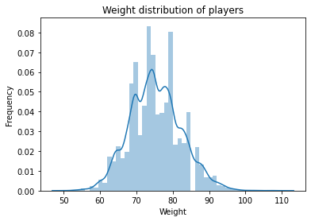

```python
#histogram
sb.distplot(fifa_df['weight'])
# Add labels
plt.title('Weight distribution of players')
plt.xlabel('Weight')
plt.ylabel('Frequency');
```

> The weight distribution looks normal.

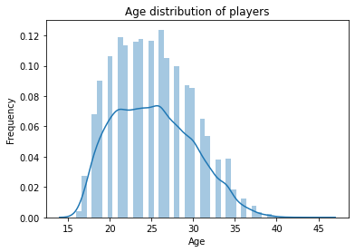

```python
sb.distplot(fifa_df['age'])

# Add labels
plt.title('Age distribution of players')
plt.xlabel('Age')
plt.ylabel('Frequency');
```

> The distribution shows that most of the players are in their 20s and it is slightly positive skewed.

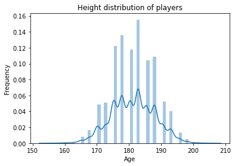

```python
sb.distplot(fifa_df['height'])

# Add labels
plt.title('Height distribution of players')
plt.xlabel('Age')
plt.ylabel('Frequency');
```

Now, Let's investigate the top 10 players Nationalities

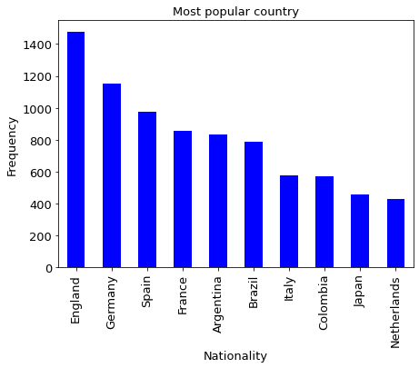

```python
nation = fifa_df.nationality.value_counts()[0:10]

#plot
g_bar = nation.plot.bar(color = 'blue', fontsize = 13)

#figure size(width, height)
g_bar.figure.set_size_inches(7, 5);

#Add labels
plt.title('Most popular country', color = 'black', fontsize = '13')
plt.xlabel('Nationality', color = 'black', fontsize = '13')
plt.ylabel('Frequency', color = 'black', fontsize = '13');
```

> The above visualization shows that England is the top footballing nation, while the only country that represents Asia is Japan.

Now, Let's investigate the top 10 football clubs

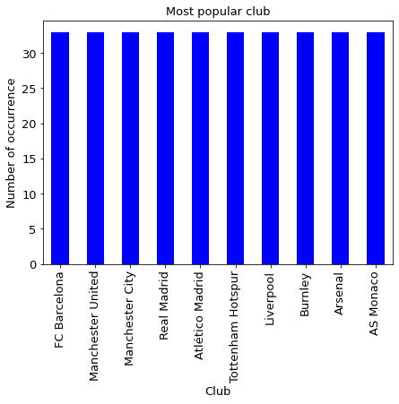

```python
club = fifa_df.club.value_counts()[0:10]

#plot
g_bar = club.plot.bar(color = 'blue', fontsize = 13)

#figure size(width, height)
g_bar.figure.set_size_inches(7, 5);

#Add labelbs
plt.title('Most popular club', color = 'black', fontsize = '13')
plt.xlabel('Club', color = 'black', fontsize = '13')
plt.ylabel('Number of occurrence', color = 'black', fontsize = '13');
```

> This result is easly expected as England is the most popular country based on our data. Therefore, we have 6 clubs from England in the Top 10 football clubs. Also, we have 3 Spanish clubs.

Now, Let's investigate the playing position which is one of the main attributes that I want to investigate

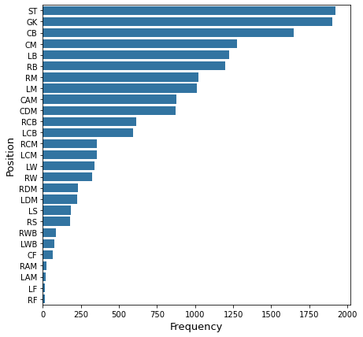

```python
position_count = fifa_df.position.value_counts()
position_order = position_count.index

ax = plt.subplots(1,1, figsize=(7,7))

base_color = sb.color_palette()[0]
sb.countplot(data = fifa_df, y = 'position', color = base_color, order = position_count.index)
plt.ylabel('Position', color = 'black', fontsize = '13')
plt.xlabel('Frequency', color = 'black', fontsize = '13');
```

> Most players are playing as a striker and then we have Goal keepers.

Nos, Lets investigate the most used foot by the players

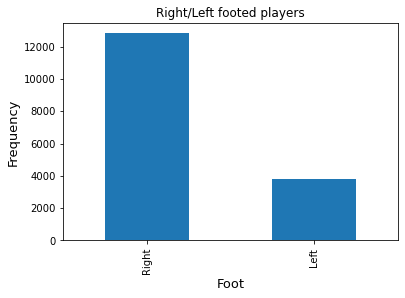

```python
fifa_df['preferred_foot'].value_counts().plot.bar(title="Right/Left footed players")
plt.ylabel('Frequency', color = 'black', fontsize = '13')
plt.xlabel('Foot', color = 'black', fontsize = '13');
```

> The bar plot shows that most of the players are Right footed.

### Discuss the distribution(s) of your variable(s) of interest. Were there any unusual points? Did you need to perform any transformations?

> **2. categorical variables**: I started with invistigating the Nationality variable. I viewed the countries that appeared most frequently in the dataset. England is at the top. Then, I had a look at the Club and it was expected to see 6 clubs from England in the top 10 clubs. After that, I had a look at the playing position. Most palyers play the position ST which is the top striker. Also, I found out that most players are right footed.

### Of the features you investigated, were there any unusual distributions? Did you perform any operations on the data to tidy, adjust, or change the form of the data? If so, why did you do this?

> When I had a look at the players Height distribution, it was looking so abnormal. Then, I noticed it was poorly format e.g 81 = 8'1. I fixed by changing the whole unit into cm. Also, some columns were having missing values like clubs, joined, contract, and I dropped the rows that are including these missing values in order to have better analysis.

## Bivariate Exploration

First, let's take a look at the correlations and relationships

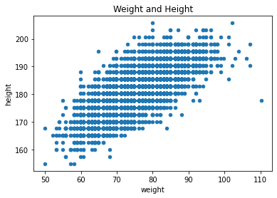

```python
# Correlation between weight and height
fifa_df.plot(x='weight', y='height', kind='scatter', title = 'Weight and Height');
```

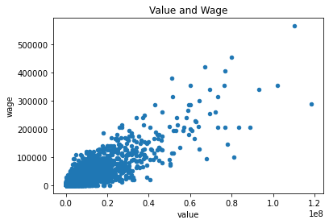

```python
# Correlation between Value and Wage
fifa_df.plot(x='value', y='wage', kind='scatter', title = 'Value and Wage');
```

> The plot shows a fairly strong relationship.

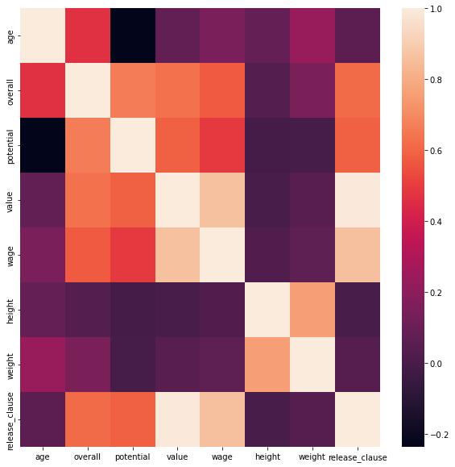

```python
fifa_hist = fifa_df[['age', 'overall', 'potential', 'value', 'wage', 'height', 'weight','release_clause',]]

# plotting heatmap
f, ax = plt.subplots(figsize=(10, 10))
corr = fifa_hist.corr()
sb.heatmap(corr,xticklabels=corr.columns.values,yticklabels=corr.columns.values);
```

**Observations**

- Age has a negative correlation with Potential.
- Wage has a positive correlation with Release clause.
- Potential has a positive correlation with Release clause.
- Value has a positive correlation with Wage.

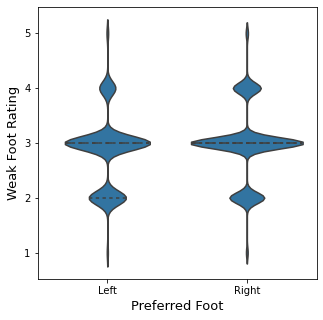

```python
# plotting violin plot
ax = plt.subplots(1,1, figsize=(5,5))

base_color = sb.color_palette()[0]
sb.violinplot(data = fifa_df, x = 'preferred_foot', y = 'weak_foot', color = base_color, inner = 'quartile')
plt.ylabel('Weak Foot Rating', color = 'black', fontsize = '13')
plt.xlabel('Preferred Foot', color = 'black', fontsize = '13');
```

> The plot shows that most players left footed or right foot had a week foot rating of 3 and a few players got a rating above 3.

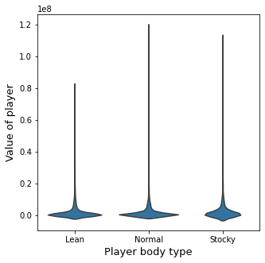

```python
# plotting violin plot
ax = plt.subplots(1,1, figsize=(5,5))

base_color = sb.color_palette()[0]
sb.violinplot(data = fifa_df, x = 'body_type', y = 'value', color = base_color, inner = None)
plt.ylabel('Value of player', color = 'black', fontsize = '13')
plt.xlabel('Player body type', color = 'black', fontsize = '13');
```

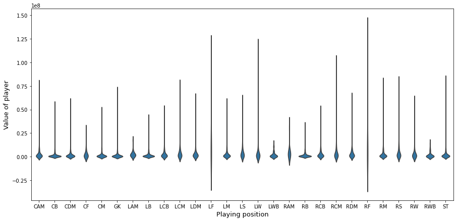

```python
# plotting violin plot
ax = plt.subplots(1,1, figsize=(15,7))

base_color = sb.color_palette()[0]
sb.violinplot(data = fifa_df, x = 'position', y = 'value', color = base_color, inner = None)
plt.ylabel('Value of player', color = 'black', fontsize = '13')
plt.xlabel('Playing position', color = 'black', fontsize = '13');
```

> The plot shows that Right Forward players are valued more while Right wing back and Left wing back players are valued lowest.

Next, let's see the distribution of players body type

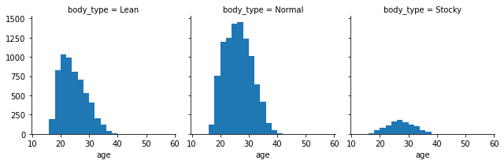

```python
# plotting Facet
bins = np.arange(12, 59, 2)
g = sb.FacetGrid(data = fifa_df, col = 'body_type')
g.map(plt.hist, 'age', bins = bins);
```

> The above plots show the distribution of Age and each player body type. It shows that most players have a normal body type while very few players have a stocky body type.

Let's look at the Top 10 clubs that pay more wages

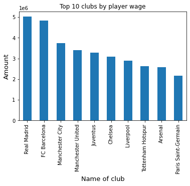

```python
# Group by club then taking the sum of the wage.
wages10 = fifa_df.groupby('club')['wage'].sum().sort_values(ascending = False).head(10)

# plotting
wages10.plot.bar(title="Top 10 clubs by player wage")
plt.ylabel('Amount', color = 'black', fontsize = '13')
plt.xlabel('Name of club', color = 'black', fontsize = '13');
```

> It shows that Real Madrid is on the top and has the most Wage which means they have a high number of high profile players.

Let's look at the Top 10 player who earn most

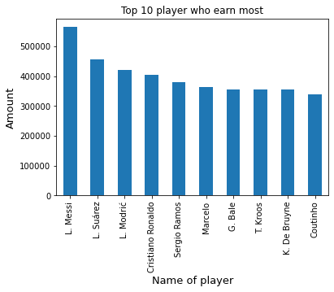

```python
# Group by name then taking the sum of the wage
p_wages10 = fifa_df.groupby('name')['wage'].sum().sort_values(ascending = False).head(10)

# plotting
p_wages10.plot.bar(title="Top 10 player who earn most")
plt.ylabel('Amount', color = 'black', fontsize = '13')
plt.xlabel('Name of player', color = 'black', fontsize = '13');
```

> It shows that Messi earns more than all other player with wage more than 500k.

Now, Let's see if nationality has an effect on the value of players

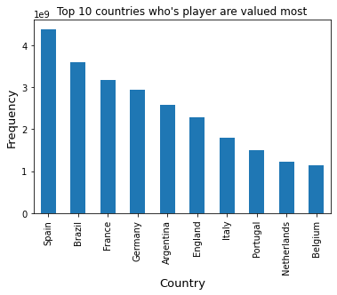

```python
# Group by nationality then taking the sum of the value
p_nation = fifa_df.groupby('nationality')['value'].sum().sort_values(ascending = False).head(10)

# plotting
p_nation.plot.bar(title="Top 10 countries who's player are valued most")
plt.ylabel('Frequency', color = 'black', fontsize = '13')
plt.xlabel('Country', color = 'black', fontsize = '13');
```

> The plot shows that Spanish and Brazilian players are valued more than other players.

Let's look at the Countries with the highest player ratings

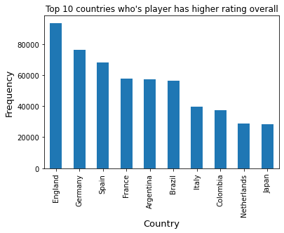

```python
# Group by nationality then taking the sum of the value
p_overall = fifa_df.groupby('nationality')['overall'].sum().sort_values(ascending = False).head(10)

# plotting
p_overall.plot.bar(title="Top 10 countries who's player has higher rating overall")
plt.ylabel('Frequency', color = 'black', fontsize = '13')
plt.xlabel('Country', color = 'black', fontsize = '13');
```

> The plot shows that England players have the highest player ratings.

### Did you observe any interesting relationships between the other features (not the main feature(s) of interest)?

> Surpisingly, Right-forward position players are valued more than other positions while the Right-wing back and Left-wing back are valued lowest.

## Multivariate Exploration

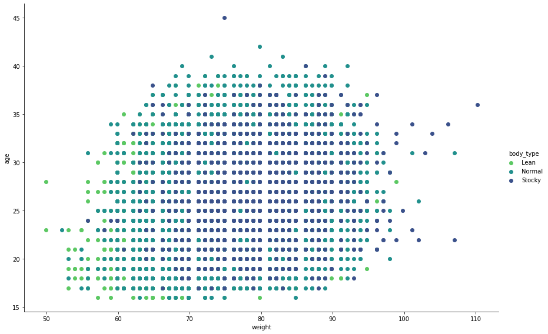

```python
# plotting facet
g = sb.FacetGrid(data = fifa_df, hue = 'body_type', size = 8, aspect = 1.5, palette = 'viridis_r')
g.map(plt.scatter, 'weight', 'age')
g.add_legend();
```

This shows me something i didn't even think about. Most of the younger players weighs lesser and they also have more of a lean body type.

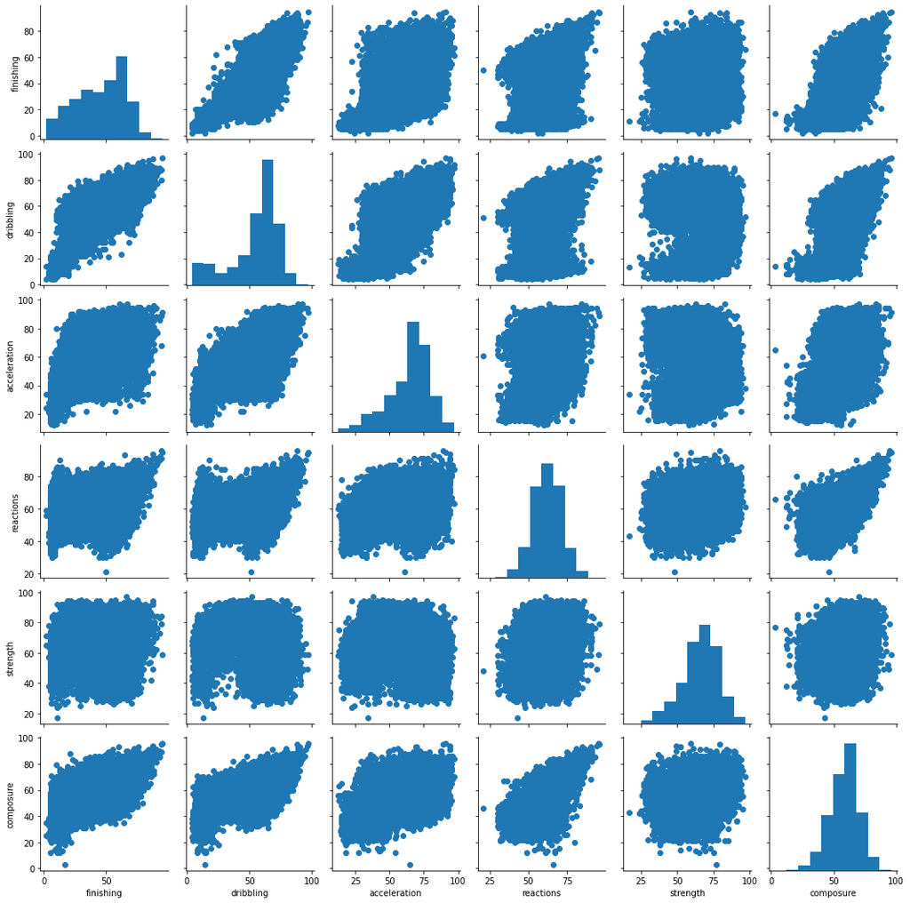

```python
# plotting

fifa_attributes = ['finishing', 'dribbling', 'acceleration', 'reactions', 'strength', 'composure']

g = sb.PairGrid(data = fifa_df, vars = fifa_attributes);
g.map_offdiag(plt.scatter);
g.map_diag(plt.hist);
```

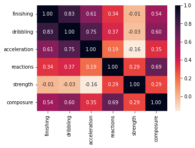

```python
# plotting heatmap
sb.heatmap(fifa_df[fifa_attributes].corr(), cmap = 'rocket_r', annot = True, fmt = '.2f');
```

**Observations**

### Were there any interesting or surprising interactions between features?

> There were some interesting correlations. When I plotted the pairwise relationships between the player's abilities, I noticed a strong positive relationship between the Finishing and Dribbling player's abilities.